# Week 4 Statistics Study Guide: Continuous & Sampling Distributions

Ken Black (Chapters 6 & 7) and Wilcox (Chapter 4.7)

Eric Schmidt

2026-11-25

# 1 Overview & Learning Objectives

The Week 4 readings cover **Chapter 6 (Continuous Distributions)** and **Chapter 7 (Sampling and Sampling Distributions)** from Ken Black’s *Business Statistics*, paired with **Wilcox Chapter 4 (Section 4.7)** on modern insights into non-normality, heavy-tailed distributions, and skewness, as well as R methods from **Teetor (Chapter 8)**. By the end of this module, you should be able to:

1. Differentiate between **discrete** (counting) and **continuous** (measuring) probability distributions, recognizing that for continuous variables $P(X = x) = 0$ and probabilities correspond to **areas under a density curve**.
2. Compute probabilities, quantiles, and summary parameters for the **Continuous Uniform**, **Normal** (and **Standard Normal $z$**), and **Exponential** distributions in R (`punif`, `pnorm`, `qnorm`, `pexp`).
3. Assess normality visually using **histograms**, **kernel density curves**, and **Normal Q-Q plots**.
4. Apply the **Normal Approximation to the Binomial Distribution** using a **continuity correction** ($\pm 0.5$) and compare approximate vs. exact binomial probabilities.
5. Distinguish **sampling** vs. **census**, **sampling** vs. **non-sampling error**, and execute **simple** and **stratified random sampling** in R (`sample()`, `sample.int()`, `set.seed()`, and grouped sampling).
6. Apply the **Central Limit Theorem (CLT)** to characterize the sampling distribution of the sample mean ($\bar{x}$) and the sample proportion ($\hat{p}$), including the **Finite Population Correction Factor**.
7. Critically evaluate the limitations of normality using **Wilcox’s contaminated (mixed) normal**, **skewness**, and **logarithmic transformation** insights.

# 2 Black Chapter 6: Continuous Distributions

Unlike discrete random variables that take countable values (e.g., counts of defects or arrivals) and sum individual probabilities, a **continuous random variable** arises from **measuring** and can assume any value over an uninterrupted interval. Probabilities are calculated over intervals $[a, b]$ via integration (the area under the probability density function $f(x)$), with total area equal to $1$ and $P(X = x) = 0$ at any single exact point.

## 2.1 The Continuous Uniform Distribution (Section 6.1)

Also known as the **rectangular distribution**, every sub-interval of equal width within $[a, b]$ has an equal probability of occurring because the density height is constant across the finite interval.

- **Probability Density Function (PDF):**
  $$f(x) = \frac{1}{b - a}, \quad \text{for } a \le x
  \le b \quad (\text{and } 0 \text{ otherwise})$$
- **Probability over Sub-interval $[x_1, x_2] \subseteq [a, b]$:**
  $$P(x_1 \le X \le x_2) = \frac{x_2 - x_1}{b -
  a}$$
- **Mean & Standard Deviation:**
  $$\mu = \frac{a + b}{2}, \qquad \sigma = \frac{b -
  a}{\sqrt{12}}$$
- **Inputs:**
  - $a$: Minimum (lower endpoint) of the uniform interval.
  - $b$: Maximum (upper endpoint) of the uniform interval ($b > a$).
  - $x_1, x_2$: Lower and upper bounds of the target probability interval (clamped to $[a, b]$).

### 2.1.1 R Implementation: Plastic Module Assembly & Table 6.1 (Black Ch. 6 R Supplement)

- **Demonstration Problem 6.1:** The time required to assemble a plastic module is uniformly distributed between $a = 27$ and $b = 39$ seconds. Thus, $\mu = 33$ seconds, $\sigma = 3.4641$ seconds, $P(30 \le X \le 35) = \frac{35 - 30}{39 - 27} = 0.4167$, and $P(X < 30) = \frac{30 - 27}{39 - 27} = 0.2500$.
- **Table 6.1 Benchmark:** For $X \sim \text{Uniform}(200, 1182)$, $P(410 \le X \le 825) = 0.4226$.

```r
a <- 27
b <- 39

mu_unif <- (a + b) / 2
sd_unif <- (b - a) / sqrt(12)
prob_30_35_manual <- (35 - 30) / (b - a)
prob_30_35_r <- punif(q = 35, min = a, max = b, lower.tail = TRUE) -
  punif(q = 30, min = a, max = b, lower.tail = TRUE)
prob_lt_30 <- punif(q = 30, min = a, max = b, lower.tail = TRUE)
prob_table_6_1 <- punif(q = 825, min = 200, max = 1182, lower.tail = TRUE) -
  punif(q = 410, min = 200, max = 1182, lower.tail = TRUE)

print(sprintf("Demo 6.1 -> Mean: %.2f | SD: %.4f", mu_unif, sd_unif))
```

```
## [1] "Demo 6.1 -> Mean: 33.00 | SD: 3.4641"
```

```r
print(sprintf("P(30 <= X <= 35) manual: %.4f | punif(): %.4f", prob_30_35_manual, prob_30_35_r))
```

```
## [1] "P(30 <= X <= 35) manual: 0.4167 | punif(): 0.4167"
```

```r
print(sprintf("P(X < 30): %.4f | Table 6.1 P(410 <= X <= 825): %.4f", prob_lt_30, prob_table_6_1))
```

```
## [1] "P(X < 30): 0.2500 | Table 6.1 P(410 <= X <= 825): 0.4226"
```

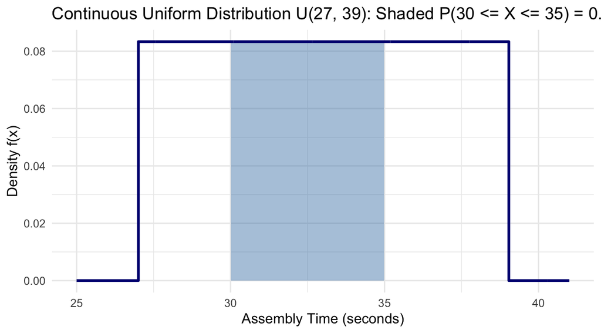

```r
unif_df <- data.frame(x = seq(25, 41, length.out = 400))
unif_df$y <- dunif(unif_df$x, min = a, max = b)

ggplot(unif_df, aes(x = x, y = y)) +
  geom_area(data = subset(unif_df, x >= 30 & x <= 35), fill = "steelblue", alpha = 0.45) +
  geom_step(color = "navy", linewidth = 1) +
  labs(title = "Continuous Uniform Distribution U(27, 39): Shaded P(30 <= X <= 35) = 0.4167",
       x = "Assembly Time (seconds)",
       y = "Density f(x)") +
  theme_minimal()
```

## 2.2 The Normal & Standard Normal Distributions (Section 6.2)

The **Normal (Gaussian) Distribution** is symmetric around its mean ($\text{Mean} = \text{Median} = \text{Mode}$), unimodal, bell-shaped, asymptotic to the horizontal axis (tails extend to $\pm\infty$ without touching the axis), and completely defined by two parameters: its mean ($\mu$) and standard deviation ($\sigma$).

- **Normal Probability Density Function:**
  $$f(x) = \frac{1}{\sigma \sqrt{2\pi}}
  e^{-\frac{1}{2}\left(\frac{x - \mu}{\sigma}\right)^2}, \quad -\infty
  < x < +\infty$$
- **Standard Normal Distribution ($Z$) & $z$-Score Transformation:** A normal distribution with $\mu = 0$ and $\sigma = 1$. Any normal variable $X \sim N(\mu, \sigma^2)$ can be standardized into a **$z$-score**, measuring how many standard deviations $x$ lies above or below $\mu$:
  $$z = \frac{x - \mu}{\sigma}$$
- **Inputs:**
  - $x$: Observed or threshold value of the normal random variable.
  - $\mu$: Population mean (center of the distribution).
  - $\sigma$: Population standard deviation ($\sigma = \sqrt{\sigma^2} > 0$, spread of the distribution).
- **Key Empirical Benchmarks:**
  - $P(\mu - \sigma < X < \mu + \sigma) \approx 0.6826$ ($68\%$)
  - $P(\mu - 1.96\sigma < X < \mu + 1.96\sigma) = 0.9500$ ($95\%$)
  - $P(\mu - 2\sigma < X < \mu + 2\sigma) \approx 0.9544$ ($95.4\%$)
  - $P(\mu - 3\sigma < X < \mu + 3\sigma) \approx 0.9973$ ($99.7\%$)

### 2.2.1 R Implementation: EPA Waste Generation & Quantiles (Black Ch. 6 R Supplement)

In **Demonstration Problem 6.3**, daily per-capita waste generation in the U.S. is normally distributed with $\mu = 4.43$ pounds and $\sigma = 1.32$ pounds. Unlike printed $z$-tables (which round $z$ to two decimal places), R computes exact cumulative probabilities via `pnorm()` directly from $\mu$ and $\sigma$ and exact inverse percentiles via `qnorm()`.

```r
mu_waste <- 4.43
sd_waste <- 1.32

z_waste <- (6.00 - mu_waste) / sd_waste
p_gt_6_z <- pnorm(q = z_waste, mean = 0, sd = 1, lower.tail = FALSE)
p_gt_6_direct <- pnorm(q = 6.00, mean = mu_waste, sd = sd_waste, lower.tail = FALSE)
p_36_50 <- pnorm(q = 5.00, mean = mu_waste, sd = sd_waste, lower.tail = TRUE) -
  pnorm(q = 3.60, mean = mu_waste, sd = sd_waste, lower.tail = TRUE)
p_53_65 <- pnorm(q = 6.50, mean = mu_waste, sd = sd_waste) -
  pnorm(q = 5.30, mean = mu_waste, sd = sd_waste)
p90_waste <- qnorm(p = 0.90, mean = mu_waste, sd = sd_waste, lower.tail = TRUE)

emp_68 <- pnorm(1) - pnorm(-1)
emp_95 <- pnorm(1.96) - pnorm(-1.96)
emp_2sd <- pnorm(2) - pnorm(-2)
emp_997 <- pnorm(3) - pnorm(-3)

print(sprintf("Normal Benchmarks -> 1SD: %.4f | 1.96SD: %.4f | 2SD: %.4f | 3SD: %.4f",
              emp_68, emp_95, emp_2sd, emp_997))
```

```
## [1] "Normal Benchmarks -> 1SD: 0.6827 | 1.96SD: 0.9500 | 2SD: 0.9545 | 3SD: 0.9973"
```

```r
print(sprintf("Demo 6.3 -> z(6.00) = %.4f | P(X > 6.00) via z: %.4f | direct: %.4f",
              z_waste, p_gt_6_z, p_gt_6_direct))
```

```
## [1] "Demo 6.3 -> z(6.00) = 1.1894 | P(X > 6.00) via z: 0.1171 | direct: 0.1171"
```

```r
print(sprintf("P(3.60 <= X <= 5.00): %.4f | P(5.30 <= X <= 6.50): %.4f | 90th percentile: %.4f lbs",
              p_36_50, p_53_65, p90_waste))
```

```
## [1] "P(3.60 <= X <= 5.00): 0.4023 | P(5.30 <= X <= 6.50): 0.1965 | 90th percentile: 6.1216 lbs"
```

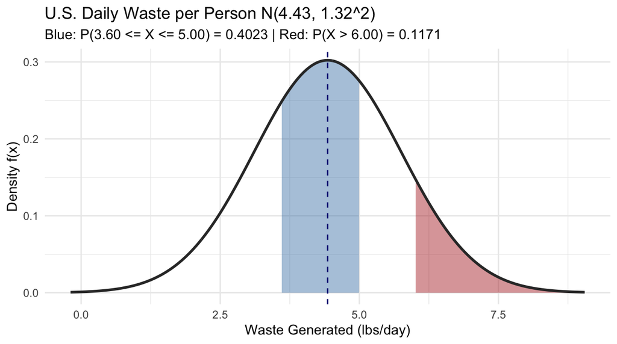

```r
x_norm <- seq(mu_waste - 3.5 * sd_waste, mu_waste + 3.5 * sd_waste, length.out = 500)
norm_df <- data.frame(x = x_norm, y = dnorm(x_norm, mean = mu_waste, sd = sd_waste))

ggplot(norm_df, aes(x = x, y = y)) +
  geom_area(data = subset(norm_df, x >= 3.60 & x <= 5.00), fill = "steelblue", alpha = 0.45) +
  geom_area(data = subset(norm_df, x >= 6.00), fill = "firebrick", alpha = 0.45) +
  geom_line(color = "gray20", linewidth = 1) +
  geom_vline(xintercept = mu_waste, linetype = "dashed", color = "navy") +
  labs(title = "U.S. Daily Waste per Person N(4.43, 1.32^2)",
       subtitle = "Blue: P(3.60 <= X <= 5.00) = 0.4023 | Red: P(X > 6.00) = 0.1171",
       x = "Waste Generated (lbs/day)",
       y = "Density f(x)") +
  theme_minimal()
```

### 2.2.2 Checking Normality Visually: CEO Ages (`salaries.csv`)

To evaluate whether empirical data plausibly follow a Normal distribution, combine a **histogram** (or kernel density plot) with a **Normal Q-Q plot** (`qqnorm()` and `qqline()`). Points aligning closely along the diagonal reference line indicate approximate normality. Using [`salaries.csv`](https://raw.githubusercontent.com/telpirion/CumulativeStudyGuide/refs/heads/main/data/salaries.csv) ($n = 60$ small-business CEOs), CEO `AGE` exhibits an approximately bell-shaped distribution and linear Q-Q alignment, whereas `SAL` is right-skewed.

```r
salaries <- read.csv("https://raw.githubusercontent.com/telpirion/CumulativeStudyGuide/refs/heads/main/data/salaries.csv")

print(sprintf("CEO AGE -> n = %d | Mean = %.2f | Median = %.2f | SD = %.2f",
              nrow(salaries), mean(salaries$AGE), median(salaries$AGE), sd(salaries$AGE)))
```

```
## [1] "CEO AGE -> n = 60 | Mean = 51.47 | Median = 50.00 | SD = 8.92"
```

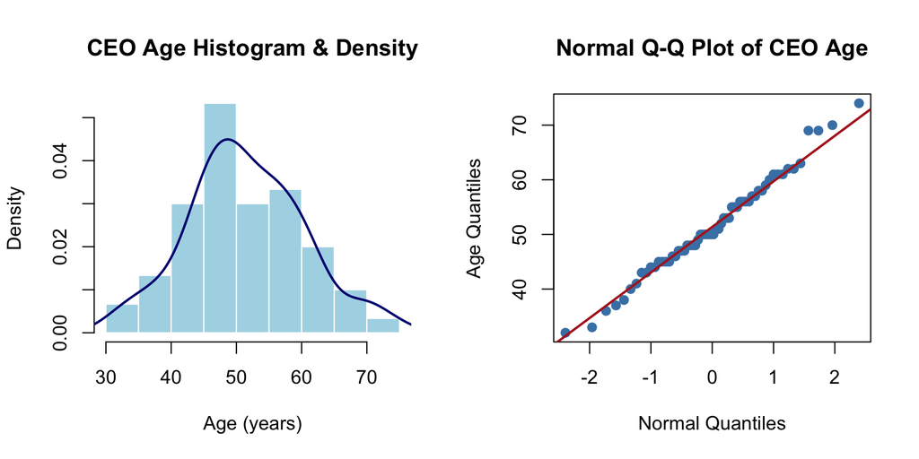

```r
par(mfrow = c(1, 2))
hist(salaries$AGE, probability = TRUE, col = "lightblue", border = "white",
     main = "CEO Age Histogram & Density", xlab = "Age (years)")
lines(density(salaries$AGE), col = "navy", lwd = 2)
qqnorm(salaries$AGE, main = "Normal Q-Q Plot of CEO Age",
       xlab = "Normal Quantiles", ylab = "Age Quantiles", pch = 19, col = "steelblue")
qqline(salaries$AGE, distribution = qnorm, probs = c(0.25, 0.75), qtype = 7, col = "firebrick", lwd = 2)
```

## 2.3 Normal Approximation to the Binomial (Section 6.3)

When the number of binomial trials $n$ is large enough that **$n p \ge 5$ and $n q \ge 5$** (where $q = 1 - p$, ensuring the interval $\mu \pm 3\sigma$ lies comfortably inside $[0, n]$), a discrete Binomial distribution $X \sim \text{Binomial}(n, p)$ can be approximated by a continuous Normal distribution $Y \sim N(\mu, \sigma^2)$ with:

$$\mu = n p, \qquad \sigma = \sqrt{n p q},
\qquad z = \frac{x_{\text{corrected}} - n p}{\sqrt{n p q}}$$

- **Inputs:**
  - $n$: Fixed number of independent Bernoulli trials.
  - $p$: Constant probability of success per trial ($q = 1 - p$).
  - $x$: Discrete integer count of successes ($0 \le x \le n$).
- **Continuity Correction ($\pm 0.5$):** Because a smooth normal curve approximates discrete integer probability bars of width $1$ centered at $x$, adjust endpoints by $0.5$ to include or exclude the boundary bar:
  - Exact value: $P(X = x) \approx P(x - 0.5 \le Y \le x + 0.5)$
  - At most $x$: $P(X \le x) \approx P(Y \le x + 0.5)$
  - Fewer than $x$: $P(X < x) = P(X \le x - 1) \approx P(Y \le x - 0.5)$
  - At least $x$: $P(X \ge x) \approx P(Y \ge x - 0.5)$
  - More than $x$: $P(X > x) = P(X \ge x + 1) \approx P(Y \ge x + 0.5)$

### 2.3.1 R Implementation: Exact Binomial vs. Normal Approximation (Black Ch. 6 R Supplement)

- **Demonstration Problem 6.6 ($n = 25, p = 0.40$):** Compare exact $P(X = 12)$ via `dbinom()` against the normal approximation over $[11.5, 12.5]$.
- **Demonstration Problem 6.7 ($n = 100, p = 0.37$):** Compare exact $P(X < 27) = P(X \le 26)$ via `pbinom()` against the normal approximation $P(Y \le 26.5)$.

```r
n_66 <- 25
p_66 <- 0.40
exact_66 <- dbinom(x = 12, size = n_66, prob = p_66)
approx_66 <- pnorm(q = 12.5, mean = n_66 * p_66, sd = sqrt(n_66 * p_66 * (1 - p_66))) -
  pnorm(q = 11.5, mean = n_66 * p_66, sd = sqrt(n_66 * p_66 * (1 - p_66)))

n_67 <- 100
p_67 <- 0.37
exact_67 <- pbinom(q = 26, size = n_67, prob = p_67, lower.tail = TRUE)
z_67 <- (26.5 - n_67 * p_67) / sqrt(n_67 * p_67 * (1 - p_67))
approx_67 <- pnorm(q = z_67, mean = 0, sd = 1)

print(sprintf("Demo 6.6 P(X = 12) -> Exact Binomial: %.6f | Normal Approx: %.6f", exact_66, approx_66))
```

```
## [1] "Demo 6.6 P(X = 12) -> Exact Binomial: 0.113950 | Normal Approx: 0.116429"
```

```r
print(sprintf("Demo 6.7 P(X < 27) -> z = %.4f | Exact Binomial: %.6f | Normal Approx: %.6f",
              z_67, exact_67, approx_67))
```

```
## [1] "Demo 6.7 P(X < 27) -> z = -2.1748 | Exact Binomial: 0.013271 | Normal Approx: 0.014823"
```

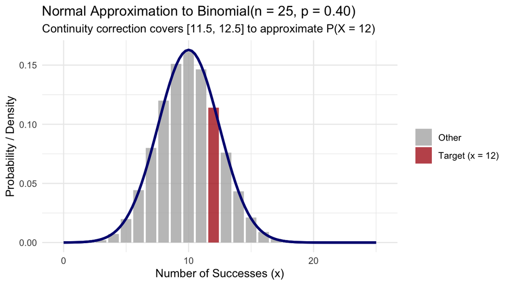

```r
mu_66 <- n_66 * p_66
sd_66 <- sqrt(n_66 * p_66 * (1 - p_66))
binom_df <- data.frame(x = 0:n_66, prob = dbinom(0:n_66, size = n_66, prob = p_66))
binom_df$highlight <- ifelse(binom_df$x == 12, "Target (x = 12)", "Other")

ggplot(binom_df, aes(x = x, y = prob, fill = highlight)) +
  geom_col(width = 0.85, alpha = 0.8) +
  stat_function(fun = dnorm, args = list(mean = mu_66, sd = sd_66),
                color = "navy", linewidth = 1.1) +
  scale_fill_manual(values = c("Other" = "gray70", "Target (x = 12)" = "firebrick")) +
  labs(title = "Normal Approximation to Binomial(n = 25, p = 0.40)",
       subtitle = "Continuity correction covers [11.5, 12.5] to approximate P(X = 12)",
       x = "Number of Successes (x)",
       y = "Probability / Density",
       fill = NULL) +
  theme_minimal()
```

## 2.4 The Exponential Distribution (Section 6.4)

The **Exponential Distribution** is the continuous counterpart to the discrete Poisson distribution: whereas Poisson counts the number of random events occurring over an interval, the Exponential distribution models the **continuous waiting time or space between independent events** occurring at a constant average rate $\lambda$. It is **positively (right) skewed**, **left-bound at zero** ($x \ge 0$), and exhibits strictly decreasing density as $x$ increases.

- **Probability Density Function (PDF):**
  $$f(x) = \lambda e^{-\lambda x}, \quad x \ge 0, \;
  \lambda > 0$$
- **Cumulative & Tail Probabilities:**
  $$P(X \le x_0) = 1 - e^{-\lambda x_0}, \qquad P(X
  \ge x_0) = e^{-\lambda x_0}$$
- **Mean & Standard Deviation:**
  $$\mu = \frac{1}{\lambda}, \qquad \sigma =
  \frac{1}{\lambda}$$
  *(Note: For the exponential distribution, the mean and standard deviation are always equal).*
- **Inputs:**
  - $\lambda$: Mean occurrence rate per **one unit** of time or space (must match the units of $x_0$).
  - $x_0$: Target waiting time or distance between consecutive events ($x_0 \ge 0$).

### 2.4.1 R Implementation: Interarrival Time Between Defects (Black Demo 6.8)

In **Demonstration Problem 6.8**, defective parts arrive in a Poisson pattern at an average rate of $1.38$ defects every $20$ minutes. Converting to a per-minute rate gives $\lambda_{\text{min}} = \frac{1.38}{20} = 0.069$ defects/minute, so the mean interarrival time is $\mu = \frac{20}{1.38} = 14.4928$ minutes. The probability that less than $15$ minutes elapse between any two defects is $P(X < 15) = 1 - e^{-0.069(15)} = 0.6448$.

```r
lambda_20 <- 1.38
mu_intervals <- 1 / lambda_20
mean_minutes <- mu_intervals * 20
rate_per_min <- 1 / mean_minutes

prob_lt_15 <- pexp(q = 15, rate = rate_per_min, lower.tail = TRUE)
prob_lt_15_formula <- 1 - exp(-rate_per_min * 15)
prob_ge_15_formula <- exp(-rate_per_min * 15)

print(sprintf("Demo 6.8 -> Mean interval: %.4f min | Rate: %.4f/min | P(X < 15): %.4f (formula: %.4f) | P(X >= 15): %.4f",
              mean_minutes, rate_per_min, prob_lt_15, prob_lt_15_formula, prob_ge_15_formula))
```

```
## [1] "Demo 6.8 -> Mean interval: 14.4928 min | Rate: 0.0690/min | P(X < 15): 0.6448 (formula: 0.6448) | P(X >= 15): 0.3552"
```

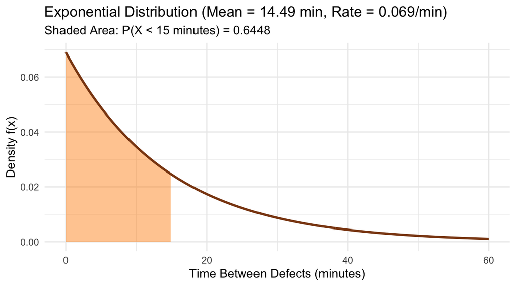

```r
x_exp <- seq(0, 60, length.out = 400)
exp_df <- data.frame(x = x_exp, y = dexp(x_exp, rate = rate_per_min))

ggplot(exp_df, aes(x = x, y = y)) +
  geom_area(data = subset(exp_df, x <= 15), fill = "darkorange", alpha = 0.45) +
  geom_line(color = "saddlebrown", linewidth = 1) +
  labs(title = "Exponential Distribution (Mean = 14.49 min, Rate = 0.069/min)",
       subtitle = "Shaded Area: P(X < 15 minutes) = 0.6448",
       x = "Time Between Defects (minutes)",
       y = "Density f(x)") +
  theme_minimal()
```

# 3 Wilcox Chapter 4 (Section 4.7): Modern Advances & Insights on Normality

Rand Wilcox (*Basic Statistics*, Section 4.7) classifies distributions along two dimensions—**symmetry** and **outlier frequency**—warning that classical normal-based inferences break down quickly under subtle, visually undetectable departures from normality.

## 3.1 Four Distribution Archetypes

1. **Symmetric with outliers rarely occurring** (includes the exact Normal distribution).
2. **Symmetric with outliers commonly occurring** (e.g., heavy-tailed / contaminated normals).
3. **Asymmetric (skewed) with outliers rarely occurring**.
4. **Asymmetric (skewed) with outliers commonly occurring**.

## 3.2 The Contaminated (Mixed) Normal Distribution

A **mixed (contaminated) normal distribution** arises when two normal populations with different variances (or means) are combined.

- **Wilcox’s Classic Illustration:** Suppose $90\%$ of adults follow a standard normal distribution ($\mu = 0, \sigma = 1$) and $10\%$ (e.g., dieters) follow a normal distribution with the same mean ($\mu = 0$) but larger spread ($\sigma = 10$).
- **Three Critical Consequences:**
  1. **Bell-Shaped $\ne$ Normal:** Visually, the mixed normal curve looks symmetric and bell-shaped, closely resembling a normal curve, **yet it is not normal** and has **heavy tails** (greater probability of extreme outliers).
  2. **Extreme Sensitivity of Variance:** While the standard normal has $\sigma^2 = 1$, this $10\%$-contaminated mixed normal inflates the population variance to **$\sigma^2 = 0.9(1^2) + 0.1(10^2) = 10.9$** ($\sigma \approx 3.30$). In samples, just a few outliers drastically inflate $s^2$ regardless of sample size.
  3. **Breakdown of the $68\%$ Rule & Equal-Variance Shape:** Under normality, $P(\mu - \sigma \le X \le \mu + \sigma) = 0.6826$. For Wilcox’s mixed normal, this probability **exceeds $0.925$**. Furthermore, two symmetric bell-shaped curves can share the exact same mean and variance yet have radically different shapes (a sharp central peak with heavy tails vs. a broad normal bell).

## 3.3 Skewness & Limitations of Logarithmic Transformations

```r
set.seed(123)
is_outlier_group <- rbinom(100000, size = 1, prob = 0.10)
mixed_sample <- ifelse(is_outlier_group == 1,
                       rnorm(100000, mean = 0, sd = 10),
                       rnorm(100000, mean = 0, sd = 1))

mixed_sd <- sd(mixed_sample)
within_1sd <- mean(abs(mixed_sample - mean(mixed_sample)) <= mixed_sd)
print(sprintf("Wilcox Mixed Normal -> Variance: %.2f | P(|X - mu| <= sigma): %.3f (vs 0.683 for Normal)",
              var(mixed_sample), within_1sd))
```

```
## [1] "Wilcox Mixed Normal -> Variance: 10.84 | P(|X - mu| <= sigma): 0.925 (vs 0.683 for Normal)"
```

```r
wilcox_vec <- c(1, 2, 3, 4, 5, 6, 7, 8, 9, 10, 200, 500)
back_transformed <- 10^(mean(log10(wilcox_vec)))
print(sprintf("Original Mean: %.2f | Original Median: %.2f | Back-Transformed Log Mean: %.2f",
              mean(wilcox_vec), median(wilcox_vec), back_transformed))
```

```
## [1] "Original Mean: 62.92 | Original Median: 6.50 | Back-Transformed Log Mean: 9.19"
```

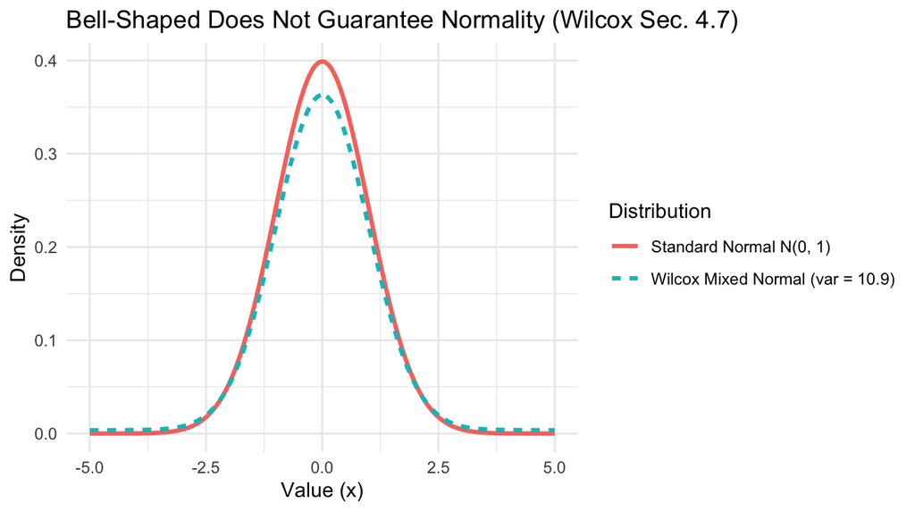

```r
x_grid <- seq(-5, 5, length.out = 500)
compare_df <- data.frame(
  x = rep(x_grid, 2),
  density = c(
    dnorm(x_grid, 0, 1),
    0.9 * dnorm(x_grid, 0, 1) + 0.1 * dnorm(x_grid, 0, 10)
  ),
  Distribution = rep(c("Standard Normal N(0, 1)", "Wilcox Mixed Normal (var = 10.9)"), each = length(x_grid))
)

ggplot(compare_df, aes(x = x, y = density, color = Distribution, linetype = Distribution)) +
  geom_line(linewidth = 1.1) +
  labs(title = "Bell-Shaped Does Not Guarantee Normality (Wilcox Sec. 4.7)",
       x = "Value (x)",
       y = "Density") +
  theme_minimal()
```

# 4 Black Chapter 7: Sampling and Sampling Distributions

## 4.1 Sampling Techniques, Frames & Error Types (Section 7.1)

- **Reasons for Sampling vs. a Census:** Sampling saves time and money and is essential when testing is **destructive** (e.g., crash-testing vehicles or stress-testing bulbs). A **census** (observing every unit) eliminates sampling error entirely when feasible.
- **Sampling Frame & Underregistration:** The directory, map, or list from which a sample is drawn is the **sampling frame**. If the frame contains fewer units than the target population, it suffers from **underregistration** (coverage bias).
- **Sampling Error:** The natural, unavoidable discrepancy between a sample statistic ($\bar{x}, \hat{p}$) and the true population parameter ($\mu, p$) arising by chance because only a subset of the population is observed.
- **Non-Sampling Error:** Errors caused by missing data, recording/data-entry mistakes, measurement problems, or non-response bias (not reduced by increasing $n$).

### 4.1.1 Probability (Random) vs. Non-Probability (Nonrandom) Sampling

1. **Probability (Random) Sampling** (every unit has a known, nonzero probability of selection):
   - **Simple Random Sample (SRS):** Every possible sample of size $n$ has an equal chance of selection.
   - **Stratified Random Sample:** Partition the population into homogeneous, non-overlapping subgroups (**strata**) and draw an SRS from each stratum. Can be **proportionate** (matching population stratum shares) or **disproportionate** (varying sampling fractions across strata).
   - **Systematic Sample:** Select every $k$-th item ($k = \lfloor N/n \rfloor$) from an ordered frame after a random start.
   - **Cluster (Area) Sample:** Divide the population into non-overlapping geographic/administrative **clusters** (areas), randomly select clusters, and sample all (or random subsets of) units within selected clusters.
2. **Non-Probability (Nonrandom) Sampling** (probabilities of selection are unknown or unequal):
   - **Convenience Sampling:** Elements chosen for ease of access to the researcher.
   - **Judgment Sampling:** Elements selected using the researcher’s expert judgment.
   - **Quota Sampling:** Nonrandom counterpart to stratified sampling (filling preset subgroup quotas non-randomly).
   - **Snowball Sampling:** Survey respondents refer additional subjects from their network.

### 4.1.2 R Implementation: Reproducible & Stratified Sampling (Black Ch. 7 R Supplement)

R provides `sample()` and `sample.int()` for random sampling, governed by the 626-element RNG state vector `.Random.seed`. Calling `set.seed()` ensures exact reproducibility. When sampling rows from a data frame like `iris`, pass row indices (`1:nrow(iris)`) to `sample()`, or use `dplyr::slice_sample()` / `sample_n()` (including grouped stratified sampling) versus base R `split()` + `lapply()` + `do.call(rbind, ...)`.

```r
our_vector <- rnorm(n = 1000, mean = 0, sd = 1)

set.seed(999)
sample_a <- sample(x = our_vector, size = 5, replace = FALSE)
set.seed(999)
sample_b <- sample(x = our_vector, size = 5, replace = FALSE)
print(sprintf("Reproducible sample match: %s", identical(sample_a, sample_b)))
```

```
## [1] "Reproducible sample match: TRUE"
```

```r
data(iris)
set.seed(8888)
iris_idx <- sample.int(n = nrow(iris), size = 6, replace = FALSE)
print(iris[iris_idx, c("Species", "Sepal.Length", "Petal.Length")])
```

```
##        Species Sepal.Length Petal.Length
## 119  virginica          7.7          6.9
## 95  versicolor          5.6          4.2
## 60  versicolor          5.2          3.9
## 132  virginica          7.9          6.4
## 64  versicolor          6.1          4.7
## 67  versicolor          5.6          4.5
```

```r
set.seed(777)
strat_dplyr <- iris %>%
  group_by(Species) %>%
  slice_sample(n = 3, replace = FALSE)
print(table(strat_dplyr$Species))
```

```
##
##     setosa versicolor  virginica
##          3          3          3
```

```r
set.seed(777)
split_iris <- split(x = iris, f = iris$Species)
iris_samples <- lapply(X = split_iris, function(df_sub) {
  df_sub[sample(x = 1:nrow(df_sub), size = 3, replace = FALSE), ]
})
strat_base <- do.call(rbind, iris_samples)
print(table(strat_base$Species))
```

```
##
##     setosa versicolor  virginica
##          3          3          3
```

## 4.2 Sampling Distribution of $\bar{x}$ & The Central Limit Theorem (Section 7.2)

The **sampling distribution of $\bar{x}$** is the probability distribution of all possible sample means computed from samples of size $n$.

- **Expected Value & Standard Error of the Mean ($\sigma_{\bar{x}}$):**
  $$\mu_{\bar{x}} = \mu, \qquad \sigma_{\bar{x}} =
  \frac{\sigma}{\sqrt{n}}$$
- **Finite Population Correction (FPC) Factor:** If sampling **without replacement** from a known finite population of size $N$ where $n > 0.05N$:
  $$\sigma_{\bar{x}} =
  \frac{\sigma}{\sqrt{n}}\sqrt{\frac{N - n}{N - 1}}$$
- **Standardizing $\bar{x}$ into a $z$-Score:**
  $$z = \frac{\bar{x} - \mu}{\sigma /
  \sqrt{n}}$$
- **Inputs:**
  - $\bar{x}$: Target sample mean value.
  - $\mu$: Population mean.
  - $\sigma$: Population standard deviation.
  - $n$: Sample size ($N$: population size when applying FPC).
- **The Central Limit Theorem (CLT):**
  - If the underlying population is **Normal**, $\bar{x}$ is exactly Normally distributed for **any** sample size $n$.
  - If the underlying population is **non-normal** (e.g., Uniform or Skewed), as sample size $n$ becomes sufficiently large (rule of thumb: **$n \ge 30$**, or larger if heavily skewed/heavy-tailed), the sampling distribution of $\bar{x}$ approaches a **Normal distribution** with mean $\mu$ and standard deviation $\sigma_{\bar{x}} = \frac{\sigma}{\sqrt{n}}$.

### 4.2.1 R Implementation: Sample Mean Probability & CLT Simulation

Below we compute $P(\bar{x} > 53)$ for a population with $\mu = 50, \sigma = 12, n = 36$, and simulate $2{,}000$ sample means drawn from a flat $\text{Uniform}(0, 1)$ population at $n = 2$, $n = 10$, and $n = 30$ to illustrate how the sampling distribution converges to a Normal bell curve with shrinking standard error $\sigma / \sqrt{n}$.

```r
mu_pop <- 50
sigma_pop <- 12
n_samp <- 36
se_xbar <- sigma_pop / sqrt(n_samp)
z_xbar <- (53 - mu_pop) / se_xbar
prob_xbar <- pnorm(z_xbar, mean = 0, sd = 1, lower.tail = FALSE)
se_fpc <- (12 / sqrt(50)) * sqrt((500 - 50) / (500 - 1))
print(sprintf("Sampling Dist z = %.2f | P(x_bar > 53): %.4f (SE = %.2f) | FPC SE (N=500, n=50): %.4f",
              z_xbar, prob_xbar, se_xbar, se_fpc))
```

```
## [1] "Sampling Dist z = 1.50 | P(x_bar > 53): 0.0668 (SE = 2.00) | FPC SE (N=500, n=50): 1.6116"
```

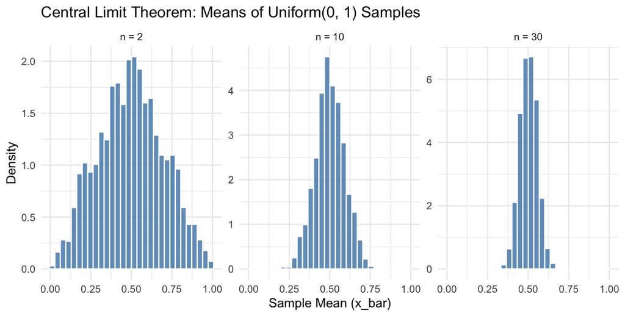

```r
set.seed(2026)
reps <- 2000
sample_sizes <- c(2, 10, 30)
clt_list <- lapply(sample_sizes, function(sz) {
  means <- replicate(reps, mean(runif(sz, min = 0, max = 1)))
  data.frame(sample_mean = means, n_label = factor(paste("n =", sz), levels = paste("n =", sample_sizes)))
})
clt_df <- do.call(rbind, clt_list)

ggplot(clt_df, aes(x = sample_mean)) +
  geom_histogram(aes(y = after_stat(density)), bins = 30, fill = "steelblue", color = "white", alpha = 0.8) +
  facet_wrap(~ n_label, scales = "free_y") +
  labs(title = "Central Limit Theorem: Means of Uniform(0, 1) Samples",
       x = "Sample Mean (x_bar)",
       y = "Density") +
  theme_minimal()
```

## 4.3 Sampling Distribution of the Sample Proportion ($\hat{p}$) (Section 7.3)

For a sample proportion $\hat{p} = \frac{x}{n}$, when **$n p \ge 5$ and $n q \ge 5$** (where $q = 1 - p$), the sampling distribution of $\hat{p}$ is approximately Normal:

- **Mean & Standard Error of the Proportion ($\sigma_{\hat{p}}$):**
  $$\mu_{\hat{p}} = p, \qquad \sigma_{\hat{p}} =
  \sqrt{\frac{p(1 - p)}{n}} = \sqrt{\frac{p q}{n}}$$
- **Standardizing $\hat{p}$ into a $z$-Score:**
  $$z = \frac{\hat{p} - p}{\sqrt{\frac{p(1 -
  p)}{n}}}$$
- **Inputs:**
  - $\hat{p} = x / n$: Sample proportion of successes ($x$: observed successes in sample).
  - $p$: True population proportion of successes ($q = 1 - p$).
  - $n$: Sample size.

```r
p_pop <- 0.60
n_prop <- 300
se_phat <- sqrt(p_pop * (1 - p_pop) / n_prop)
z_phat <- (0.53 - p_pop) / se_phat
prob_phat <- pnorm(z_phat, mean = 0, sd = 1, lower.tail = TRUE)
print(sprintf("Sampling Dist of p_hat (p = 0.60, n = 300) -> SE: %.4f | z = %.4f | P(p_hat <= 0.53): %.4f",
              se_phat, z_phat, prob_phat))
```

```
## [1] "Sampling Dist of p_hat (p = 0.60, n = 300) -> SE: 0.0283 | z = -2.4749 | P(p_hat <= 0.53): 0.0067"
```

# 5 Week 4 Key Formula Summary Sheet

| Distribution / Concept | Density / Statistic Formula | Mean ($\mu$) & Std. Dev. ($\sigma$) | R Functions & Key Conditions |
| --- | --- | --- | --- |
| **Continuous Uniform** | $f(x) = \frac{1}{b - a}$ ($a \le x \le b$) | $\mu = \frac{a+b}{2}$, $\sigma = \frac{b-a}{\sqrt{12}}$ | `dunif()`, `punif()`, `qunif()`, `runif()` |
| **Normal / Standard Normal** | $z = \frac{x - \mu}{\sigma}$ | $\mu$, $\sigma$ (for $Z$: $0, 1$) | `dnorm()`, `pnorm()`, `qnorm()`, `rnorm()`; $68\text{--}95\text{--}99.7$ fails under heavy tails |
| **Binomial Normal Approx.** | $z = \frac{(x \pm 0.5) - np}{\sqrt{npq}}$ | $\mu = np$, $\sigma = \sqrt{npq}$ | Valid when $np \ge 5$ and $nq \ge 5$; apply $\pm 0.5$ continuity correction |
| **Exponential** | $f(x) = \lambda e^{-\lambda x}$, $P(X \ge x) = e^{-\lambda x}$ | $\mu = \frac{1}{\lambda}$, $\sigma = \frac{1}{\lambda}$ | `dexp()`, `pexp()`, `qexp()`; right-skewed, left-bound at $0$ |
| **Sampling Dist. of $\bar{x}$** | $z = \frac{\bar{x} - \mu}{\sigma / \sqrt{n}}$ | $\mu_{\bar{x}} = \mu$, $\sigma_{\bar{x}} = \frac{\sigma}{\sqrt{n}}$ | Normal if pop. is normal or $n \ge 30$ (CLT); use FPC if $n > 0.05N$ |
| **Sampling Dist. of $\hat{p}$** | $z = \frac{\hat{p} - p}{\sqrt{pq/n}}$ | $\mu_{\hat{p}} = p$, $\sigma_{\hat{p}} = \sqrt{\frac{pq}{n}}$ | Valid when $np \ge 5$ and $nq \ge 5$ |

## Navigation & Practice

- **Practice & Exercises:** [Week 4 Practice & Exercises (Jupyter Notebook)](https://colab.research.google.com/github/telpirion/CumulativeStudyGuide/blob/main/Week4.ipynb)
- **Next Lesson:** Week 5 Study Guide — Statistical Estimation & Modern Robust Intervals